# Lab 3, CP 4: Testes de hipótese

## 1. Dataset

Os dados utilizados durante esta análise foram coletados por meio do registro de logs dos eventos ocorridos durante interações de usuários no site do Wikipédia no período entre 01 a 08 de março no ano 2016. Estes dados foram disponibilizados pela organização sem fins lucrativos que gerencia o site da Wikipédia, a Wikimedia Foundation.

```r
buscas = read_csv(here::here("data/search_data.csv"))
```

A coleta dos dados teve objetivo de identificar diferenças no uso do site por dois diferentes grupos (a e b), cada grupo utilizava um diferente modo de buscar por conteúdo no site. A tabela abaixo apresenta a quantidade de sessões para cada grupo estudado.

```r
buscas %>%
    group_by(grupo = group) %>%
    summarise(quantidade_sessao = n())
```

| grupo | quantidade_sessao |
| --- | --- |
| a | 29427 |
| b | 38601 |

Nesse contexto, com o objetivo investigar as diferentes formas de buscar por conteúdos no site, eram registradas informações durante a realização de cada evento pelo usuário, possibilitando a obtenção de conhecimentos sobre a ação realizada (busca, clique no resultado da busca, tempo de permanência na página), quantos resultados foram retornados nas buscas, qual a posição o usuário clicou ao visitar uma página e etc.

Para esta análise, os dados foram agrupados considerando cada sessão existente e sumarizando as informações de cada evento no nível de sessão. Desta forma, esta pesquisa propõe responder às seguintes perguntas:

1. Qual é a taxa de cliques nos diferentes dias? Como isso varia nos dois grupos?
2. Considerando os resultados das buscas, o resultado de qual posição os usuário tendem a clicar? Como isso muda durantes os diferentes dias?

A fim de responder essas perguntas, foram identificados alguns pontos a serem considerados durante a análise:

- *Em todos os 8 dias existem sessões contidas entre as faixas de 1h a 23:59h (24h)*;
- *Existem sessões que não possuem busca ou páginas visitadas que não apresentam a posição que resultou em seu acesso:* Estes dois contextos, foram consideradas como inatividade do usuário por mais de 10 min, o que resultou na criação de novas sessões com tais informações ausentes.

Ainda nesse contexto, com o objetivo de responder as perguntas foram utilizadas as seguintes variáveis:

- *num_clicks:* número de ocorrência do evento de visitar página;
- *taxa de cliques:* proporção de cliques, nas sessões com pelo menos uma página visitada;
- *session_start_date:* data e hora do primeiro evento registrado na sessão;
- *group:* grupo ao qual a sessão pertence, variando entre a e b;
- *position_clicked:* mediana da posição escolhida pelo usuário durantes visitas de páginas em cada sessão.
- *session_durantion_sec:* tempo de duração da sessão em segundos.

## 2. Taxa de cliques no decorrer dos dias

Considerando a taxa de cliques diária como a proporção de cliques em todas as sessões em cada dia e divindo os dados entre os grupos a e b, foi investigada a primeira pergunta. Com base nessa análise, a Figura 1 foi produzida.

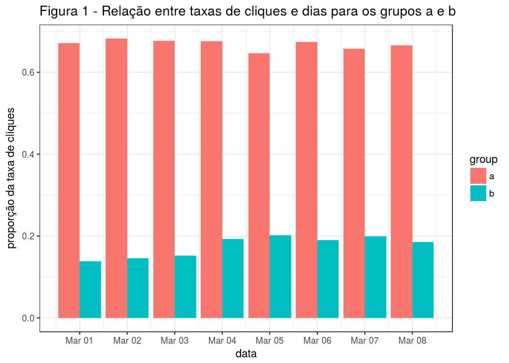

```r
buscas %>%
    group_by(data = as.Date(session_start_date), group) %>%
    summarise(taxa_cliques = sum(num_clicks > 0)/n()) %>%
    ggplot(aes(x = as.Date(data), y = taxa_cliques, fill = group)) +
    geom_col(position = "dodge") +
    scale_x_date(date_labels="%b %d", date_breaks  ="1 day") +
    labs(y= "proporção da taxa de cliques", x= "data", title="Figura 1 - Relação entre taxas de cliques e dias para os grupos a e b")
```

Com base na Figura 1, é notável que apesar de existirem mais sessões do grupo b, a sua taxa de cliques diária é mais baixa se comparado ao grupo b em todos os dias, ficando aproximadamente entre 0.1 e 0.2. Já considerando o grupo a proporção da taxa de cliques diária ficou entre 0.6 a 0.68, variando pouco entre os 8 dias. Além disso, é observado que os dias que apresentaram as menores proporções de cliques foram dia 01 de março de 2016 no grupo b e dia 05 de março de 2016 no grupo a.

Com base nos resultados obtidos por meio da Figura 1, foi optado pela realização de testes de hipóteses para verificar se (1) existe uma diferença significativa entre a proporção da taxa de cliques nos grupos a e b e (2) se existe diferença significativa entre as maiores e menores prorpoções apresentadas nos dois grupos entre os dias com a maior e menor proporção da taxa de cliques.

Nesse contexto, inicialmente foi investigado se existia uma diferença significativa entre as prorporções de taxa de cliques do dia 02 (maior proporção) e 05 (menor proporção) de março no grupo a.

```r
fun.select.dia <- function(buscas, data_um_str, data_dois_str, grupo) {
    return(buscas %>% filter(group == grupo & (as.Date(session_start_date, format= "%Y-%m-%d")  == data_um_str | as.Date(session_start_date, format= "%Y-%m-%d")  == data_dois_str)))
}

fun.calcula.permutation <- function(data) {
    return(permutationTest2(data, sum(!is.na(num_clicks) & num_clicks > 0)/length(num_clicks), treatment = as.Date(session_start_date, format= "%Y-%m-%d")))
}

#dias com maiores e menores proporções respectivamente
filtra.por.dia.dois.e.cinco.gp.a <- fun.select.dia(buscas ,"2016-03-02", "2016-03-05", 'a')
pt.por.dia.dois.e.cinco.gp.a = fun.calcula.permutation(filtra.por.dia.dois.e.cinco.gp.a)

df = data.frame(dias_comparados = '02 Março e 05 Março', p_value = c(pt.por.dia.dois.e.cinco.gp.a$stats$PValue), 'grupo' = c('a'))
df
```

| dias_comparados | p_value | grupo |
| --- | --- | --- |
| 02 Março e 05 Março | 0.0002 | a |

Por meio da Tabela apresentada acima, é possível identificar um diferença significativa entre a proporções de taxas de cliques encontradas nos dias 02 de março e 05 de março no grupo a, devido seu p-value = 0.0002. Nessa análise, foi considerado significativos p-values com valor inferior a 0.05.

Para o grupo b, foi analisado a existência de uma diferença significativa entre os dias 05 e 01 de março, respectivamente apresentando a maior e a menor proporção entre todos os dias do grupo. Assim, com objetivo de melhor exposição dos resultados a tabela abaixo foi construída. Nela é possível identificar o p-value encontrado para a relação.

```r
#dias com maiores e menores proporções respectivamente
filtra.por.dia.cinco.e.um.gp.b <- fun.select.dia(buscas ,"2016-03-05", "2016-03-01", 'b')

pt.por.dia.cinco.e.um.gp.b = fun.calcula.permutation(filtra.por.dia.cinco.e.um.gp.b)

df = data.frame(dias_comparados = '01 Março e 05 Março', p_value = c(pt.por.dia.cinco.e.um.gp.b$stats$PValue), 'grupo' = c('b'))
df
```

| dias_comparados | p_value | grupo |
| --- | --- | --- |
| 01 Março e 05 Março | 0.0002 | b |

Da mesmo forma da Tabela mostrada anteriormente, podemos afirmar que existe uma diferença staticamente significativa entre os dias 01 e 05 de março no grupo b.

Com base, nessas afirmações podemos reijeitar ambas e hipoteses nulas e concluir que existe uma diferença significativa entre os dias com maiores e menores proproções de taxas de cliques em ambos os grupos.

```r
pt = permutationTest2(buscas, sum(num_clicks > 0)/length(num_clicks), treatment = group)
df = data.frame(dias_comparados = 'grupo a e b', p_value = c(pt$stats$PValue))
df
```

| dias_comparados | p_value |
| --- | --- |
| grupo a e b | 0.0002 |

Como é possível observar na Tabela acima, os grupos a e b apresentam uma diferença significativa no que diz respeito a proporção da taxa de cliques (p-value = 0.0002).

Com base nesses resultados, é notável que as investigações propostas em (1) e (2), apresentaram-se como verdadeiras.

## 3. Posição que os usuários mais clicam nos diferentes dias

Com objetivo de verificar a posição média clicada pela amostra, a Figura 2 foi desenvolvida. Ela aprsenta a média da posição clicada para os 8 dias investigados.

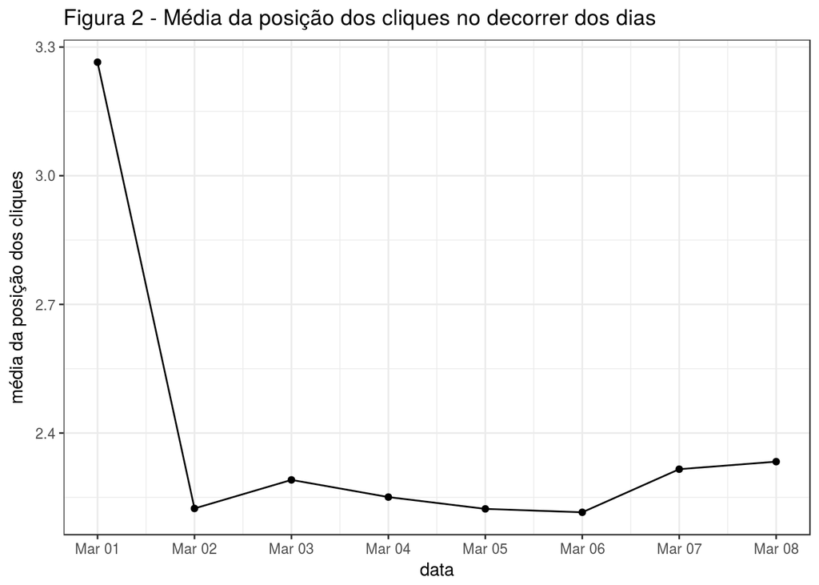

```r
buscas %>%
    filter(!is.na(position_clicked)) %>%
    group_by(data =  as.Date(session_start_date, format= "%Y-%m-%d")) %>%
    summarise(media = mean(position_clicked)) %>%
    ggplot(aes(y = media, x = data)) +
    geom_point() + geom_line() +
    scale_x_date(date_labels="%b %d", date_breaks  ="1 day") +
    labs(y= "média da posição dos cliques", title="Figura 2 - Média da posição dos cliques no decorrer dos dias")
```

Nesse contexto, surgiu a necessidade de verificar se existe um diferença significativa no que diz respeito a média do dia 01 de marçoe em comparação com os dias 02, 03, 04, 05, 06, 07 e 08 de março, devido a este apresentar um valor de média mais destoante dentre os demais dias. Para isso, foi utilizado testes de hipóteses, com objetivo de verificar a existência de diferenças entre os 01 de março com os demais dias descritos anteriormente. Assim, a Figura 3, expões os resultados obtidos com a aplicação desses testes, por meios dos p-value dessas relações.

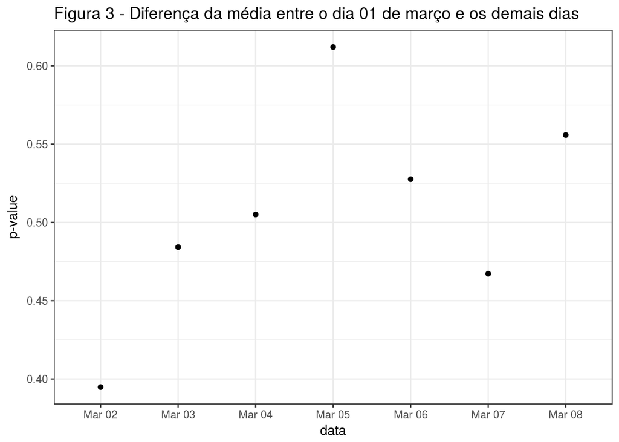

```r
fun.select.dia <- function(buscas, datr_str) {
    return(buscas %>% filter(!is.na(position_clicked) & (as.Date(session_start_date, format= "%Y-%m-%d")  == "2016-03-01" | as.Date(session_start_date, format= "%Y-%m-%d")  == datr_str)))
}

fun.calcula.permutation <- function(data) {
    return(permutationTest2(data, mean(position_clicked), treatment = as.Date(session_start_date, format= "%Y-%m-%d")))
}

sessoes.dia.um.e.dia.dois <- fun.select.dia(buscas ,"2016-03-02")
sessoes.dia.um.e.dia.tres <- fun.select.dia(buscas ,"2016-03-03")
sessoes.dia.um.e.dia.quatro <- fun.select.dia(buscas ,"2016-03-04")
sessoes.dia.um.e.dia.cinco <- fun.select.dia(buscas ,"2016-03-05")
sessoes.dia.um.e.dia.seis <- fun.select.dia(buscas ,"2016-03-06")
sessoes.dia.um.e.dia.sete <- fun.select.dia(buscas ,"2016-03-07")
sessoes.dia.um.e.dia.oito <- fun.select.dia(buscas ,"2016-03-08")

pt.dia.um.e.dia.dois = fun.calcula.permutation(sessoes.dia.um.e.dia.dois)
pt.dia.um.e.dia.tres = fun.calcula.permutation(sessoes.dia.um.e.dia.tres)
pt.dia.um.e.dia.quatro = fun.calcula.permutation(sessoes.dia.um.e.dia.quatro)
pt.dia.um.e.dia.cinco = fun.calcula.permutation(sessoes.dia.um.e.dia.cinco)
pt.dia.um.e.dia.seis = fun.calcula.permutation(sessoes.dia.um.e.dia.seis)
pt.dia.um.e.dia.sete = fun.calcula.permutation(sessoes.dia.um.e.dia.sete)
pt.dia.um.e.dia.oito = fun.calcula.permutation(sessoes.dia.um.e.dia.oito)

df = data.frame(data = c('Mar 02', 'Mar 03', 'Mar 04', 'Mar 05', 'Mar 06', 'Mar 07', 'Mar 08'),
                p_value = c(pt.dia.um.e.dia.dois$stats$PValue, pt.dia.um.e.dia.tres$stats$PValue, pt.dia.um.e.dia.quatro$stats$PValue, pt.dia.um.e.dia.cinco$stats$PValue, pt.dia.um.e.dia.seis$stats$PValue, pt.dia.um.e.dia.sete$stats$PValue, pt.dia.um.e.dia.oito$stats$PValue))

df %>%
    ggplot(aes(y = p_value, x = data)) +
    geom_point()+
    labs(y= "p-value", title="Figura 3 - Diferença da média entre o dia 01 de março e os demais dias")
```

Com base na Figura 3, é possível observar que não existe diferença significativa entre o dia 01 de março e os demais dias comparados, pois o p-value mais baixo encontrado está entre a diferença entre o dia 01 e 02 de março, possuindo um p-value = 0.39, o que não considerado significativo, adotanto como p-value < 0.05 para relações que possam apresentar alguma significância.

## 4. Vantagens e Desvantagens de usar Testes de hipóteses em relação a Intervalos de confiança

Apesar que testes de hipóteses apresentarem um único valor para ser análisado (pode ser uma vantagem), o p-value, eles necessitam de certa cautela no seu uso. Ao afirmar que algo é diferente significativo, é importante ter um clara noção do quê é um p-value significativo, pois pode existir diferentes níveis de significância em diferentes contextos. Por exemplo, 0.02 é menos significativo que 0.00002, mas na maioria dos contextos, ambos poderíam ainda sim ser significativos. No mais, é extramamente necessário possuir um cuidado especial na defição do quê é significativo. Além disso, no contexto de leitores pouco entendidos sobre a definição do teste de hipótese utilizado, é possível que o p-value possa ser tornar confuso e até mesmo seja interpretado de maneira errada.

Já utilizando dos Intervalos de Confiança, podemos de forma mais clara dizer que um certo valor está ou não em determinada faixa de valores, facilitando o entendimento. Desta forma, é possível aumentar a posibilidade de pessoas que não pertencem ao contexto do trabalho consigam obter um fácil e concreto entendimento acerca da análise.